# Games EDA

Deepak Kumar

2017-07-18

Loading required libraries,

```r
setwd("C:/Users/Deepak kumar/Downloads")
getwd()
```

```
## [1] "C:/Users/Deepak kumar/Downloads"
```

```r
library(ggplot2)
library(tidyr)
library(dplyr)
library(plotly)
library(wordcloud)
library(ggvis)
```

# 1 Reading Data

we first read data and store it in game,

```r
game=read.csv("ign.csv",stringsAsFactors = FALSE,header=TRUE)
names(game)
```

```
##  [1] "X"              "score_phrase"   "title"          "url"
##  [5] "platform"       "score"          "genre"          "editors_choice"
##  [9] "release_year"   "release_month"  "release_day"
```

From the column names,I find url and X irrelevant for our study.So let us drop them

```r
game$url=NULL
game$X=NULL
```

# 2 Find out the duplicate values

```r
names(game)
```

```
## [1] "score_phrase"   "title"          "platform"       "score"
## [5] "genre"          "editors_choice" "release_year"   "release_month"
## [9] "release_day"
```

```r
length(unique(game$title))
```

```
## [1] 12589
```

It is seen that out of 18625 observations there are 12589 unique games released and rated.Now,Let us examine the 6036 duplicated values in title column.

```r
dupli=game[which(duplicated(game$title)==TRUE),] %>% arrange(desc(score))
glimpse(dupli)
```

```
## Observations: 6,036
## Variables: 9
## $ score_phrase   <chr> "Masterpiece", "Masterpiece", "Masterpiece", "M...
## $ title          <chr> "Magical Tetris Challenge", "The Legend of Zeld...
## $ platform       <chr> "Game Boy Color", "Wii", "PlayStation 3", "Play...
## $ score          <dbl> 10.0, 10.0, 10.0, 10.0, 10.0, 10.0, 10.0, 10.0,...
## $ genre          <chr> "Puzzle, Adventure", "Action, Adventure", "Acti...
## $ editors_choice <chr> "Y", "Y", "Y", "Y", "Y", "Y", "Y", "Y", "Y", "Y...
## $ release_year   <int> 2000, 2007, 2008, 2008, 2010, 2010, 2011, 2013,...
## $ release_month  <int> 2, 2, 4, 4, 11, 10, 5, 9, 11, 11, 4, 1, 1, 1, 8...
## $ release_day    <int> 28, 26, 29, 25, 16, 27, 25, 16, 17, 17, 14, 25,...
```

It is seen from the dataset that for the title has been used and released by 2 major platforms.

Lets us now turn our attention towards the platform with maximum number of releases

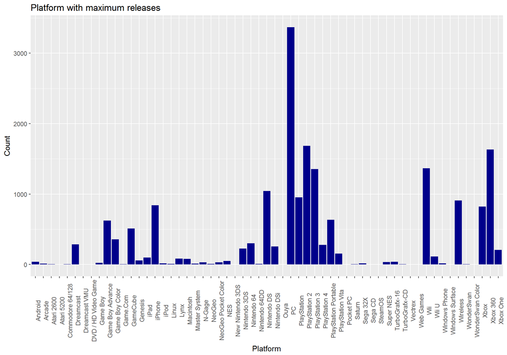

```r
game %>% select(platform,score_phrase) %>%  group_by(platform) %>% summarise(count=n()) %>% arrange(desc(count)) %>% ggplot(aes(platform,count))+geom_bar(stat="identity",fill="darkblue")+theme(axis.text.x = element_text(angle=90))+labs(x="Platform",y="Count")+ggtitle("Platform with maximum releases")
```

It is seen that PC has had the maximum game releases between 1970 to 2016.

# 3 Which platform has been consistent for 22 years ??

let us now analyse which platform has been consistent in providing games that has enthralled people with rating of great,Amazing and Masterpiece and has been the editors choice.

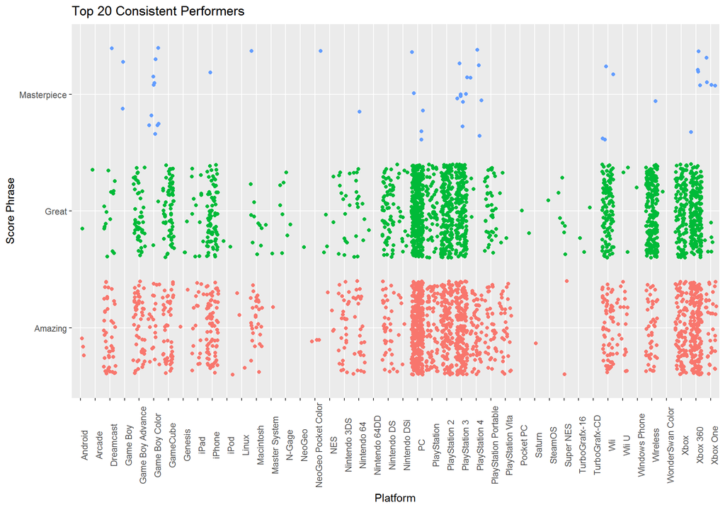

```r
game %>% select(platform,score_phrase,editors_choice)  %>% filter(editors_choice %in%"Y") %>% filter((score_phrase == "Amazing" || score_phrase=="Great" ||score_phrase =="Masterpiece")) %>% top_n(20) %>% ggplot(aes(platform,score_phrase,fill=score_phrase))+geom_jitter(stat="identity",aes(colour=score_phrase))+theme(axis.text.x = element_text(angle=90),legend.position="None")+labs(x="Platform",y="Score Phrase")+ggtitle("Top 20 Consistent Performers")
```

Hmm,most of the platforms have produced either Amazing or Great games consistently for 46 years.

# 4 Game release under Genre:

Let us examine the enere under which maximum number of games have been produced.

```r
length(unique(game$genre))
```

```
## [1] 113
```

There are 113 unique genres.

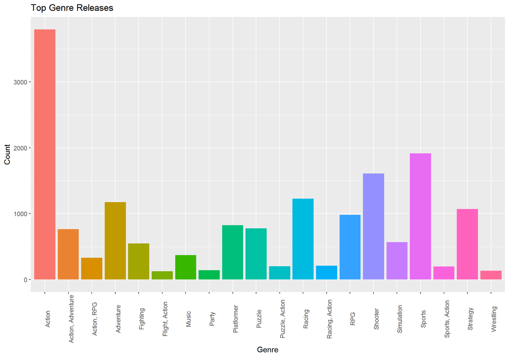

```r
count=game %>%  group_by(genre) %>% summarise(count=n()) %>% arrange(desc(count))
count %>% top_n(20) %>% ggplot(aes(genre,count,fill=genre))+geom_bar(stat="identity")+theme(axis.text.x=element_text(angle=90),legend.position="None")+labs(x="Genre",y="Count")+ggtitle("Top Genre Releases")
```

Action,Sports,Shooter,Racing tops the list.

# 5 Platform with Maximum games

Let us examine which platform has provided us maximum games for the past 22 years.

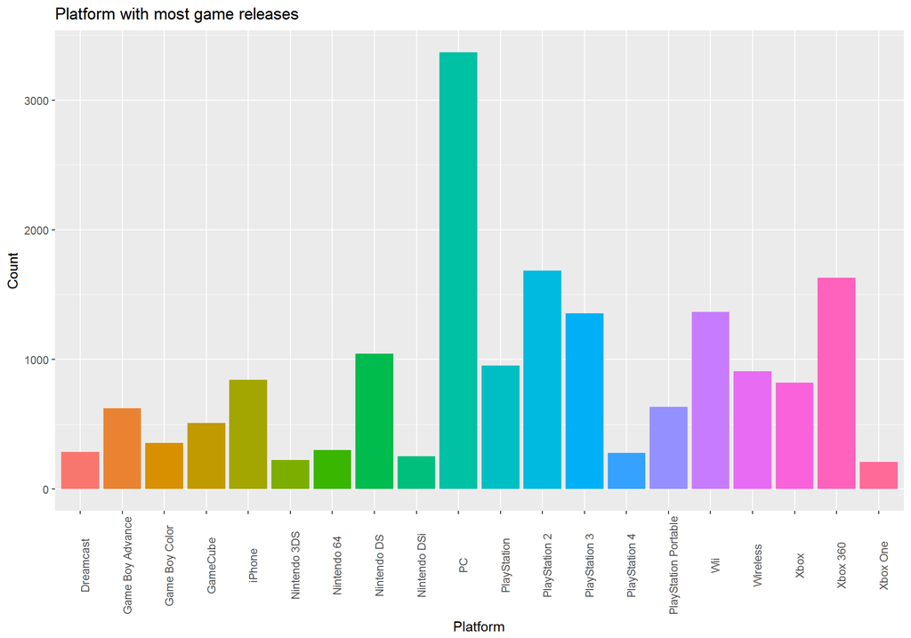

```r
game %>% group_by(platform) %>% summarise(count=n()) %>%top_n(20) %>% ggplot(aes(platform,count,fill=platform))+geom_bar(stat="identity")+labs(x="Platform",y="Count")+theme(axis.text.x = element_text(angle=90),legend.position="None")+ggtitle("Platform with most game releases")
```

More analysis is required in the platform column since the platforms like Playstation are under Sony and hence can be combined into one.From a larger prespective,we see PC,Playstation and Xbox(Microsoft) having maximum releases.

# 6 Maximum number of releases month

The analysis of game releases in the year and month will present interesting insights.Let us examine if there is any pattern on the release month and games turning out to be blockbusters.

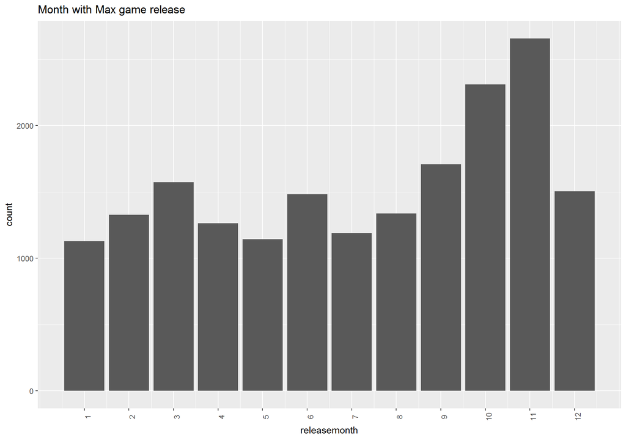

```r
game %>% group_by(release_month) %>% summarise(count=n()) %>% arrange(desc(count)) %>% ggplot(aes(release_month,count))+geom_bar(stat="identity")+labs(x="releasemonth",y="count")+theme(axis.text.x = element_text(angle=90),legend.position="None")+ggtitle("Month with Max game release")+scale_x_continuous(breaks =seq(1,12,1))
```

November has had the maximum number of game releases.